# Lecture 12: Numerical Methods for Partial Differential Equations

## Objectives

- Introduction
  - Second Order PDE Classification
  - Initial and Boundary Conditions
  - Black-Scholes Equation
- Finite Difference Methods for Solving PDEs
  - Discretization
  - Finite Difference Methods
  - The Explicit Methods
  - The Implicit Methods
  - The Crank-Nicholson Method
  - Consistency, Stability and Convergence
- Numerical Examples
  - Vanilla European Call
  - Up-And-Out Barrier Call

# Introduction

- In finance, most partial differential equations (PDE) we encounter are of the form

$$ \renewcommand{PDut}{\frac{\partial u}{\partial t}} \renewcommand{PDux}{\frac{\partial u}{\partial x}} \renewcommand{PDutt}{\frac{\partial ^2u}{\partial t^2}} \renewcommand{PDuxx}{\frac{\partial ^2u}{\partial x^2}} \renewcommand{PDuyy}{\frac{\partial ^2u}{\partial y^2}} \large{ a(x,t)\PDutt + 2b(x,t)\frac{\partial ^2u}{\partial t\partial x} + c(x,t)\PDuxx + d(x,t)\PDut + e(x,t)\PDux = f(t,x,u) } $$

- Classified into: **Hyperbolic, Parabolic and Elliptic**
- In general, the different types of equations make a big difference in how the solutions behave and
- On how we can solve them more effectively

## Classification

### Hyperbolic

- $b^2(x,t) - a(x,t)c(x,t) > 0 $

  $\;$
- The canonical form:

$$ \large{ \PDutt = c^2 \PDuxx } $$

- Mostly referred to as the **Wave equation**

### Parabolic

- $b^2(x,t) - a(x,t)c(x,t) = 0 $

  $\;$
- The canonical form:

$$ \large{ \PDut = d \;\PDuxx } $$

- Mostly referred to as the **Heat equation**

### Elliptic

- $b^2(x,y) - a(x,y)c(x,y) < 0 $

  $\;$
- The canonical form:

$$ \large{ \PDuxx + \PDuyy = 0 } $$

- Mostly referred to as the **Laplace or Poisson equation**. The solutions are **Harmonic** functions, describing e.g. the gravitational, electric potentials.

## Initial and Boundary Conditions

- Depending on the problem, we usually have **initial conditions (IC)**

$$ \large{ x(x, t=0) = u_0(x) } $$

- and/or **boundary conditions (BC)**

$$ \large{ a \; u + b\; \PDux = c, \;\forall \; x \in \partial Q, \;\forall \; t } $$

- and the BC is called **Dirichlet** if $b = 0$, **Neumann** if $a = 0$, and **Robin** otherwise .

## **Black-Scholes** Equation

$$ \renewcommand{PDuS}{\frac{\partial u}{\partial S}} \renewcommand{PDuSS}{\frac{\partial ^2u}{\partial S^2}} \PDut + \frac{1}{2}\sigma^2S^2\PDuSS + rS\PDuS - ru = 0 $$

- It belongs to the parabolic type, and can be converted into the standard Heat equation form by a change-of-variables
- For **European Call** option, the "initial" (the payoff function) and boundary conditions are

\begin{aligned} &u(S,T) = \max(S-K, 0); \\ &u(0,t) = 0; \\ &u(S,t) = S - Ke^{-r(T-t)}, \;\mbox{as } \; S \rightarrow \infty \end{aligned}

- For **European Put** option, the "initial" (the payoff function) and boundary conditions are

\begin{aligned} \renewcommand{FDut}{\frac{u_{i,k+1}-u_{i,k}}{\triangle t}} \renewcommand{FDutb}{\frac{u_{i,k}-u_{i,k-1}}{\triangle t}} \renewcommand{FDutc}{\frac{u_{i,k+1}-u_{i,k-1}}{2\triangle t}} \renewcommand{FDutt}{\frac{u_{i,k+1}-2u_{i,k}+u_{i,k-1}}{\triangle t^2}} \renewcommand{FDux}{\frac{u_{i+1,k}-u_{i,k}}{\triangle x}} \renewcommand{FDuxb}{\frac{u_{i,k}-u_{i-1,k}}{\triangle x}} \renewcommand{FDuxc}{\frac{u_{i+1,k}-u_{i-1,k}}{2\triangle x}} \renewcommand{FDuxx}{\frac{u_{i+1,k}-2u_{i,k}+u_{i-1,k}}{\triangle x^2}} &u(S,T) = \max(K-S, 0); \\ &u(0,t) = Ke^{-r(T-t)}; \\ &u(S,t) = 0, \;\mbox{as } \; S \rightarrow \infty \end{aligned}

# Finite Difference Methods for Solving PDEs

- Very rare that the PDEs have closed form solutions, in general, can only be solved numerically.
- Will focus on the finite difference method (FDM): other numerical methods exist and can be more appropriate---very much depends on the actual problems at hand.

## Discretization

- First step in solving PDEs using FDM is to represent the solution $u(x,t)$ as a discrete collection of values at a well distributed grid points in space and time in the proper domain.
- For example, for the rectangular domain in space and time with $t \in [0, T]$ and $x\in [x_{min}, x_{max}]$, we can represent the points simply as $t_0 = 0, t_1, t_2, \cdots, t_M = T$ in time and $x_0 = x_{min}, x_1, x_2, \cdots, x_N = x_{max}$ in space. The grid is uniform, i.e. $t_{k+1} = t_k + \triangle t, \;\triangle t = \frac{T}{M}$ and $x_{i+1} = x_i + \triangle x, \;\triangle x = \frac{x_{max}-x_{min}}{N}$.
- The discretized version of the solution will be represented by the values of

$$ u_{i,k} = u(x_i, t_k), \;\mbox{for } i = 0,1,\cdots,N, \mbox{ and } k = 0,1,\cdots,M $$

- The values of $u(x,t)$ at any other desired points can be approximated via interpolation.
- A uniform mesh may not necessary be the most efficient form to work with, in fact, it rarely is.
- A greatly simplified rule-of-thumb: the mesh needs to be refined around the region where the function varies a lot
- On the other hand, the mesh can be relatively coarse if the function is smooth and changing slowly
- How do I know where to put more points and where to put less before knowing the solution: concepts of adaptive mesh
- In finance, the time grid is well advised to keep the **important** dates as grid points: such as cash flow dates, contractual schedule dates, etc. The spacing of these dates is most likely not uniform.

## Finite Difference Methods(FDM)

- Toolkit for finite difference approximation

| Partial Derivative | Finite Difference | Type | Order |
| --- | --- | --- | --- |
| $\PDux$ | $\FDux$ | forward | 1st in $x$ |
| $\PDux$ | $\FDuxb$ | backward | 1st in $x$ |
| $\PDux$ | $\FDuxc$ | central | 2nd in $x$ |
| $\PDuxx$ | $\FDuxx$ | symmetric | 2nd in $x$ |
| $\PDut$ | $\FDut$ | forward | 1st in $t$ |
| $\PDut$ | $\FDutb$ | backward | 1st in $t$ |
| $\PDut$ | $\FDutc$ | central | 2nd in $t$ |
| $\PDutt$ | $\FDutt$ | symmetric | 2nd in $t$ |

## The Explicit Method

- For convenience, reverse the time for Black-Scholes notation: $ t \leftarrow T - t$

$$ \PDut - \frac{1}{2}\sigma^2S^2\PDuSS - rS\PDuS + ru = 0 $$

- Approximate the Black-Scholes Eqn by

$$ \FDut - \frac{1}{2} \sigma^2 x_i^2 \FDuxx - r x_i \FDuxc + r u_{i,k} = 0 $$

- This can be rewritten simply as

\begin{aligned} u_{i,k+1} & = \left\{ \frac{1}{2}\sigma^2 x_i^2 \frac{\triangle t}{\triangle x^2} - r x_i \frac{\triangle t}{2\triangle x} \right\} u_{i-1,k} \\ & + \left\{ 1 - \sigma^2 x_i^2 \frac{\triangle t}{\triangle x^2} -r \triangle t \right\} u_{i,k} \\ & + \left\{ \frac{1}{2}\sigma^2 x_i^2 \frac{\triangle t}{\triangle x^2} + r x_i \frac{\triangle t}{2\triangle x} \right\} u_{i+1,k} \end{aligned}

## The Implicit Method

- Approximate the Black-Scholes Eqn by

$$ \FDutb - \frac{1}{2} \sigma^2 x_i^2 \FDuxx - r x_i \FDuxc = - r u_{i,k} $$

- Which can be rewritten as

\begin{aligned} u_{i,k-1} & = \left\{ -\frac{1}{2}\sigma^2 x_i^2 \frac{\triangle t}{\triangle x^2} + r x_i \frac{\triangle t}{2\triangle x} \right\} u_{i-1,k} \\ & + \left\{ 1 + \sigma^2 x_i^2 \frac{\triangle t}{\triangle x^2} + r \triangle t \right\} u_{i,k} \\ & + \left\{ -\frac{1}{2}\sigma^2 x_i^2 \frac{\triangle t}{\triangle x^2} - r x_i \frac{\triangle t}{2\triangle x} \right\} u_{i+1,k} \end{aligned}

## The Crank-Nicholson Method

- Crank-Nicholson is an average of the explicit and implicit scheme:

\begin{aligned} \FDut & = \frac{1}{4} \sigma^2 x_i^2 \left\{ \FDuxx + \frac{u_{i+1,k+1}-2u_{i,k+1}+u_{i-1,k+1}}{\triangle x^2} \right\} \\ & + \frac{1}{2} r x_i \left\{ \FDuxc + \frac{u_{i+1,k+1}-u_{i-1,k+1}}{2\triangle x} \right\} \\ & - \frac{1}{2} r \left\{ u_{i,k} + u_{i,k+1} \right\} \end{aligned}

## Consistency, Stability and Convergence

- For any FDM that are used to solve practical problems, we should ask
  - 1) How acurate is the method?
  - 2) Does it converge?
  - 3) What is the best choice of step sizes?

### Consistency

- For the explicit method above, the local truncation error is

$$ T(x,t) = O(\triangle x^2 + \triangle t) $$

- Taylor series expansion can verify this (or one can simply read this off of the Toolkit Table).
- So the explicit method above is consistent of order 1 in time and order 2 in spatial variable.

### Fourier (Von Neumann) Stability Analysis

- The Fourier method of analyzing the stability of FDM boils down to substitute $u_{j,k}$ with

$$ \epsilon_{j,k} = e^{a t_k}e^{il_mx_j} $$

- The logic behind this: assuming $v_{j,k}$ is the solution of the FDM that did not suffer from finite precision arithmetic and is without the round off error, then the error

$$ \epsilon_{j,k} = v_{j,k} - u_{j,k} $$

$\hspace{0.2in}$ again satifies the FDM due to linearity.

- Looking for $\epsilon_{j,k} $ in the Fourier expansion representation,

$$ \epsilon(x,t) = \sum_{m= 1}^{M} e^{at}e^{il_mx} $$

where $e^{at}$ is a special form of the amplitude, and $l_m$ is the wavelength: $l_m = \frac{\pi m}{L}, m = 1, \cdots, M, \mbox{ and } M = \frac{L}{\triangle x}$

- Due to linearity again, the error analysis can be performed (without any loss of generality) by looking at a single term of the expansion

$$ e^{at_k}e^{il_mx_j} $$

- In fact, we are really interested in the amplification of the error,

$$ \frac{\epsilon_{j,k+1}}{\epsilon_{j,k}} = e^{a\triangle t} $$

- The stability analysis in the Fourier method is simply to analyze the form of $e^{a\triangle t}$ so that

$$ ||e^{a\triangle t}|| < 1 $$

- For the explicit method,

\begin{aligned} e^{a (t_k + \triangle t)}e^{il_mx_j} & = \left\{ \frac{1}{2}\sigma^2 x_j^2 \frac{\triangle t}{\triangle x^2} - r x_j \frac{\triangle t}{2\triangle x} \right\} e^{a t_k}e^{il_mx_{j-1}} \\ & + \left\{ 1 - \sigma^2 x_j^2 \frac{\triangle t}{\triangle x^2} -r \triangle t \right\} e^{a t_k}e^{il_mx_j} \\ & + \left\{ \frac{1}{2}\sigma^2 x_j^2 \frac{\triangle t}{\triangle x^2} + r x_j \frac{\triangle t}{2\triangle x} \right\} e^{a t_k}e^{il_mx_{j+1}} \end{aligned}

- Simplify it into,

\begin{aligned} e^{a\triangle t} & = \left\{ \frac{1}{2}\sigma^2 x_j^2 \frac{\triangle t}{\triangle x^2} - r x_j \frac{\triangle t}{2\triangle x} \right\} e^{-il_m\triangle x} \\ & + \left\{ 1 - \sigma^2 x_j^2 \frac{\triangle t}{\triangle x^2} -r \triangle t \right\} \\ & + \left\{ \frac{1}{2}\sigma^2 x_j^2 \frac{\triangle t}{\triangle x^2} + r x_j \frac{\triangle t}{2\triangle x} \right\} e^{il_m\triangle x} \end{aligned}

- Looking at the simple case that $r = 0$,

\begin{aligned} e^{a\triangle t} & = \frac{1}{2}\sigma^2 x_j^2 \frac{\triangle t}{\triangle x^2} e^{-il_m\triangle x} \\ & + 1 - \sigma^2 x_j^2 \frac{\triangle t}{\triangle x^2} \\ & + \frac{1}{2}\sigma^2 x_j^2 \frac{\triangle t}{\triangle x^2} e^{il_m\triangle x} \end{aligned}

- which is

\begin{aligned} e^{a\triangle t} &= \sigma^2 x_j^2 \frac{\triangle t}{\triangle x^2} \cos(l_m\triangle x) + 1 - \sigma^2 x_j^2 \frac{\triangle t}{\triangle x^2} \\ & = 1 - \sigma^2 x_j^2 \frac{\triangle t}{\triangle x^2} \cdot 2\sin^2(l_m\triangle x/2) \end{aligned}

- The stability condition will be saisfied if

$$ || 1 - \sigma^2 x_j^2 \frac{\triangle t}{\triangle x^2} \cdot 2\sin^2(l_m\triangle x/2) || < 1 $$

- Or if

$$ \triangle t < \frac{\triangle x^2}{ \sigma^2 x_{max}^2 } $$

- Which is the CFL condition for the explicit method. This says for the explicit method to be stable, the time step needs to be pretty small.
- $r\neq 0$ case?

### Lax Theorem: Consistency + Stability = Convergence

- The **Lax equivalence theorem** holds for PDE as well.
- Takeaway: when implementing FDM for PDEs, study the **CFL (Courant–Friedrichs–Lewy)** stability condition before building your discretization grid.
- For the Implicit method, the local truncation error

$$ T(x,t) = O(\triangle x^2 + \triangle t) $$

- And the amplification factor for $r=0$

$$ e^{a\triangle t} = \frac{1}{1 + \sigma^2 x_j^2 \frac{\triangle t}{\triangle x^2} \cdot 2\sin^2(l_m\triangle x/2)} $$

- So the implicit method is unconditionally stable.
- For the Crank-Nicholson method, the local truncation error is (Note: expanding the Taylor series at $(i, k+\frac{1}{2})$)

$$ T(x,t) = O(\triangle x^2 + \triangle t^2) $$

- The stability anaylsis will be one of your homeworks.

# Numerical Examples

- Black Scholes formulae and FDM methods for vanilla European call and up-and-out Barrier Call.

```
Elapsed Time: 0.00399994850159
```

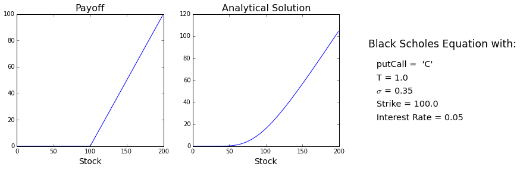

```python
%matplotlib inline
import numpy as np
import matplotlib.pyplot as plt
from scipy.stats import norm
import time

#Black and Scholes
def BlackScholesFormula(type, S0, K, r, sigma, T):
    dtmp1 = np.log(S0 / K)
    dtmp2 = 1.0/(sigma * np.sqrt(T))
    sigsq = 0.5 * sigma * sigma
    d1 =  dtmp2 * (dtmp1 + T * (r + sigsq))
    d2 =  dtmp2 * (dtmp1 + T * (r - sigsq))
    if type=="C":
        return S0 * norm.cdf(d1) - K * np.exp(-r * T) * norm.cdf(d2)
    else:
        return K * np.exp(-r * T) * stats.cdf(-d2) - S0 * norm.cdf(-d1)

K = 100.0
r = 0.05
sigma = 0.35
T = 1
putCall ='C'

Smin = 0.0
Smax = 200.0
ns = 201
Ss = np.linspace(Smin, Smax, ns, endpoint=True)
Ss = Ss[1:-1]
#print Ss

t=time.time()
px = BlackScholesFormula(putCall, Ss, K, r, sigma, T)
elapsed=time.time()-t
#print px
print "Elapsed Time:", elapsed
#idx = 200-1
#print Ss[idx]
#print px[idx]

payoff = np.clip(Ss-K, 0.0, 1e600)
#print "payoff = ", payoff

fig = plt.figure(figsize=(15,4))
ax = fig.add_subplot(1,3,1)
ax.plot(Ss, payoff)
plt.xlabel('Stock', fontsize=14);
plt.title('Payoff' , fontsize=16);

ax = fig.add_subplot(1,3,2)
ax.plot(Ss, px)
plt.xlabel('Stock', fontsize=14);
plt.title('Analytical Solution' , fontsize=16);

ax = fig.add_subplot(1,3,3)
ax.set_axis_off()
K = 100.0
r = 0.05
sigma = 0.35
T = 1
putCall ='C'
ax.text(0, .2, "   Interest Rate = 0.05 ", size="x-large");
ax.text(0, .3, "   Strike = 100.0 ", size="x-large");
ax.text(0, .4, "   $\sigma$ = 0.35 ", size="x-large");
ax.text(0, .5, "   T = 1.0 ", size="x-large");
ax.text(0, .6, "   putCall =  'C' ", size="x-large");
ax.text(0, .75, "Black Scholes Equation with:", size="xx-large");

plt.show()
```

```python
from scipy import sparse
import scipy.sparse.linalg.dsolve as linsolve

class BS_FDM_explicit:
  def __init__(self,
               r,
               sigma,
               maturity,
               Smin,
               Smax,
               Fl,
               Fu,
               payoff,
               nt,
               ns):
    self.r  = r
    self.sigma = sigma
    self.maturity  = maturity

    self.Smin = Smin
    self.Smax = Smax
    self.Fl = Fl
    self.Fu = Fu

    self.nt  = nt
    self.ns  = ns

    self.dt = float(maturity)/nt
    self.dx = float(Smax-Smin)/(ns+1)
    self.xs = Smin/self.dx

    self.u = np.empty((nt + 1, ns))
    self.u[0,:] = payoff

    ## Building Coefficient matrix:
    A = sparse.lil_matrix((self.ns, self.ns))

    for j in xrange(0, self.ns):
      xd = j + 1 + self.xs
      sx = self.sigma * xd
      sxsq = sx * sx

      dtmp1 = self.dt * sxsq
      dtmp2 = self.dt * self.r
      A[j,j] = 1.0 - dtmp1 - dtmp2
      dtmp1 = 0.5 * dtmp1
      dtmp2 = 0.5 * dtmp2 * xd
      if j > 0:
        A[j,j-1] = dtmp1 - dtmp2
      if j < self.ns - 1:
        A[j,j+1] = dtmp1 + dtmp2

    self.A = A.tocsr()

    ### Building bc_coef:
    nxl = 1 + self.xs
    sxl = self.sigma * nxl
    nxu = self.ns + self.xs
    sxu = self.sigma * nxu

    self.blcoef = 0.5 * self.dt * (sxl * sxl - self.r * nxl)
    self.bucoef = 0.5 * self.dt * (sxu * sxu + self.r * nxu)

  def solve(self):
    for i in xrange(0, m):
        self.u[i+1,:]          = self.A * self.u[i,:]
        self.u[i+1,0]         += self.blcoef * self.Fl[i]
        self.u[i+1,self.ns-1] += self.bucoef * self.Fu[i]

    return self.u

print "ESTIMATE THE TIME STEPS THROUGH CFL Condition: \n"
dx = (Smax - Smin)/(ns-1)
print "\tns(number of spatial steps) =", ns
print "\tdx (spatial size) =", dx
print "\tvolatility =", sigma
print "\tSmax =", Smax
dt_max = dx*dx/(sigma*sigma*Smax*Smax)
print "\tby CFL, dt <", dt_max
mt_min = int(T/dt_max)+1
print "\tTime Steps ~= ", mt_min
```

```
ESTIMATE THE TIME STEPS THROUGH CFL Condition:

	ns(number of spatial steps) = 201
	dx (spatial size) = 0.6
	volatility = 0.35
	Smax = 120
	by CFL, dt < 0.000204081632653
	Time Steps ~=  4901
```

```
SOLVING for the Vanilla Call Using the Explicit FDM method:
	Elapsed Time1: 0.0469999313354
	Elapsed Time2: 0.0460000038147
	Elapsed Time3: 0.0439999103546
```

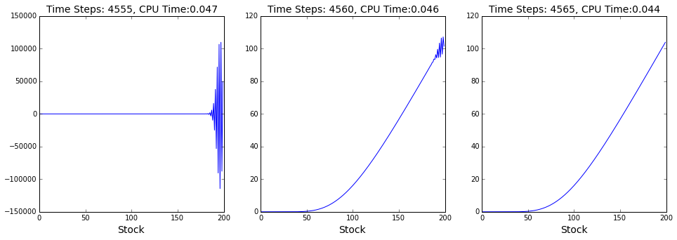

```python
print "SOLVING for the Vanilla Call Using the Explicit FDM method: "
n = ns-2
X = np.linspace(0.0, Smax, n+2)
X = X[1:-1]

payoff = np.clip(X-K, 0.0, 1e600)
#print "payoff = ", payoff

m = 4555
Fl = np.zeros((m+1,))
Fu = Smax - K*np.exp(-r * np.linspace(0.0, T, m+1))

t = time.time()
bs1 = BS_FDM_explicit(r, sigma, T, Smin, Smax, Fl, Fu, payoff, m, n)
px_fd_mat = bs1.solve()
elapsed=time.time()-t
print "\tElapsed Time1:", elapsed

##print  px_fd_mat.shape
nrow = len(px_fd_mat[:,1])
#print px_fd_mat[nrow-1,:]

fig = plt.figure(figsize=(16,5))
ax = fig.add_subplot(1,3,1)
ax.plot(X, px_fd_mat[nrow-1,:])
plt.xlabel('Stock', fontsize=14);
plt.title('Time Steps: %.f, CPU Time:%.3g'%(m, elapsed), fontsize=14);

m = 4560
Fl = np.zeros((m+1,))
Fu = Smax - K*np.exp(-r * np.linspace(0.0, T, m+1))

t = time.time()
bs2 = BS_FDM_explicit(r, sigma, T, Smin, Smax, Fl, Fu, payoff, m, n)
px_fd_mat = bs2.solve()
elapsed=time.time()-t
print "\tElapsed Time2:", elapsed

ax = fig.add_subplot(1, 3, 2)
nrow = len(px_fd_mat[:,1])
ax.plot(X, px_fd_mat[nrow-1,:])
plt.xlabel('Stock', fontsize=14);
plt.title('Time Steps: %.f, CPU Time:%.3g'%(m, elapsed), fontsize=14);

m = 4565
Fl = np.zeros((m+1,))
Fu = Smax - K*np.exp(-r * np.linspace(0.0, T, m+1))

t = time.time()
bs3 = BS_FDM_explicit(r, sigma, T, Smin, Smax, Fl, Fu, payoff, m, n)
px_fd_mat = bs3.solve()
elapsed=time.time()-t
print "\tElapsed Time3:", elapsed

ax = fig.add_subplot(1, 3, 3)
nrow = len(px_fd_mat[:,1])
ax.plot(X, px_fd_mat[nrow-1,:])
plt.xlabel('Stock', fontsize=14);
plt.title('Time Steps: %.f, CPU Time:%.3g'%(m, elapsed), fontsize=14);

plt.show()
```

```
SOLVING for the UP-AND-OUT Barrier Call Using the Explicit FDM method:
	Elapsed Time1: 0.047000169754
	Elapsed Time2: 0.0480000972748
	Elapsed Time3: 0.0480000972748
```

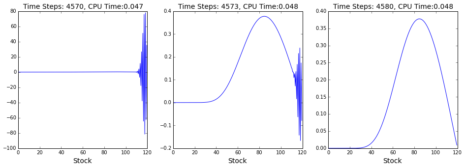

```python
print "SOLVING for the UP-AND-OUT Barrier Call Using the Explicit FDM method: "
Smax = 120
n = ns-2
X = np.linspace(0.0, Smax, n+2)
X = X[1:-1]

payoff = np.clip(X-K, 0.0, 1e600)
#print "payoff = ", payoff

m = 4570
Fl = np.zeros((m+1,))
Fu = np.zeros((m+1,))

t = time.time()
bs1 = BS_FDM_explicit(r, sigma, T, Smin, Smax, Fl, Fu, payoff, m, n)
px_fd_mat = bs1.solve()
elapsed=time.time()-t
print "\tElapsed Time1:", elapsed

##print  px_fd_mat.shape
nrow = len(px_fd_mat[:,1])
#print px_fd_mat[nrow-1,:]


fig = plt.figure(figsize=(16,5))
ax = fig.add_subplot(1,3,1)
ax.plot(X, px_fd_mat[nrow-1,:])
plt.xlabel('Stock', fontsize=14);
plt.title('Time Steps: %.f, CPU Time:%.3g'%(m, elapsed), fontsize=14);

m = 4573
Fl = np.zeros((m+1,))
Fu = np.zeros((m+1,))

t = time.time()
bs2 = BS_FDM_explicit(r, sigma, T, Smin, Smax, Fl, Fu, payoff, m, n)
px_fd_mat = bs2.solve()
elapsed=time.time()-t
print "\tElapsed Time2:", elapsed

ax = fig.add_subplot(1, 3, 2)
nrow = len(px_fd_mat[:,1])
ax.plot(X, px_fd_mat[nrow-1,:])
plt.xlabel('Stock', fontsize=14);
plt.title('Time Steps: %.f, CPU Time:%.3g'%(m, elapsed), fontsize=14);

m = 4580
Fl = np.zeros((m+1,))
Fu = np.zeros((m+1,))

t = time.time()
bs3 = BS_FDM_explicit(r, sigma, T, Smin, Smax, Fl, Fu, payoff, m, n)
px_fd_mat = bs3.solve()
elapsed=time.time()-t
print "\tElapsed Time3:", elapsed

ax = fig.add_subplot(1, 3, 3)
nrow = len(px_fd_mat[:,1])
ax.plot(X, px_fd_mat[nrow-1,:])
plt.xlabel('Stock', fontsize=14);
plt.title('Time Steps: %.f, CPU Time:%.3g'%(m, elapsed), fontsize=14);
```

```
SOLVING for the Vanilla Call Using the Implicit FDM method:
	Elapsed Time1: 0.061999797821
	Elapsed Time2: 0.0260000228882
	Elapsed Time3: 0.00899982452393
```

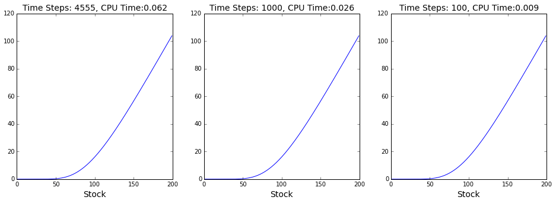

```python
print "SOLVING for the Vanilla Call Using the Implicit FDM method: "
Smax = 200
n = ns-2
X = np.linspace(0.0, Smax, n+2)
X = X[1:-1]

payoff = np.clip(X-K, 0.0, 1e600)

m = 4555
Fl = np.zeros((m+1,))
Fu = Smax - K*np.exp(-r * np.linspace(0.0, T, m+1))

t = time.time()
bs1 = BS_FDM_implicit(r, sigma, T, Smin, Smax, Fl, Fu, payoff, m, n)
px_fd_mat = bs1.solve()
elapsed=time.time()-t
print "\tElapsed Time1:", elapsed

#print  px_fd_mat.shape

fig = plt.figure(figsize=(16,5))
ax = fig.add_subplot(1, 3, 1)
nrow = len(px_fd_mat[:,1])
ax.plot(X, px_fd_mat[nrow-1,:])
plt.xlabel('Stock', fontsize=14);
plt.title('Time Steps: %.f, CPU Time:%.3g'%(m, elapsed), fontsize=14);

m = 1000
Fl =np. zeros((m+1,))
Fu = Smax - K*np.exp(-r * np.linspace(0.0, T, m+1))

t = time.time()
bs2 = BS_FDM_implicit(r, sigma, T, Smin, Smax, Fl, Fu, payoff, m, n)
px_fd_mat = bs2.solve()
elapsed=time.time()-t
print "\tElapsed Time2:", elapsed

ax = fig.add_subplot(1, 3, 2)
nrow = len(px_fd_mat[:,1])
ax.plot(X, px_fd_mat[nrow-1,:])
plt.xlabel('Stock', fontsize=14);
plt.title('Time Steps: %.f, CPU Time:%.3g'%(m, elapsed), fontsize=14);

m = 100
Fl = np.zeros((m+1,))
Fu = Smax - K*np.exp(-r * np.linspace(0.0, T, m+1))

t = time.time()
bs3 = BS_FDM_implicit(r, sigma, T, Smin, Smax, Fl, Fu, payoff, m, n)
px_fd_mat = bs3.solve()
elapsed=time.time()-t
print "\tElapsed Time3:", elapsed

ax = fig.add_subplot(1, 3, 3)
nrow = len(px_fd_mat[:,1])
ax.plot(X, px_fd_mat[nrow-1,:])
plt.xlabel('Stock', fontsize=14);
plt.title('Time Steps: %.f, CPU Time:%.3g'%(m, elapsed), fontsize=14);


#print px_fd_mat[nrow-1,:]
```

```
SOLVING for the UP-AND-OUT Barrier Call Using the Implicit FDM method:
	Elapsed Time1: 0.0620000362396
	Elapsed Time2: 0.0190000534058
	Elapsed Time3: 0.00800013542175
```

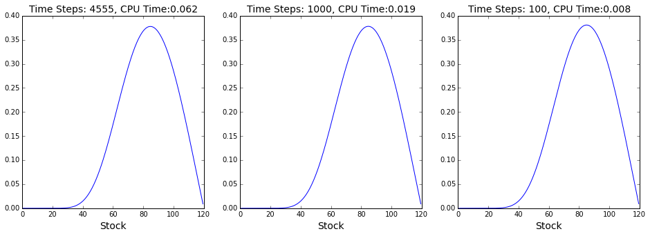

```python
print "SOLVING for the UP-AND-OUT Barrier Call Using the Implicit FDM method: "
Smax = 120

n = ns-2
X = np.linspace(0.0, Smax, n+2)
X = X[1:-1]

payoff =np.clip(X-K, 0.0, 1e600)

m = 4555
Fl = np.zeros((m+1,))
Fu = np.zeros((m+1,))

t = time.time()
bs1 = BS_FDM_implicit(r, sigma, T, Smin, Smax, Fl, Fu, payoff, m, n)
px_fd_mat = bs1.solve()
elapsed=time.time()-t
print "\tElapsed Time1:", elapsed

#print  px_fd_mat.shape

fig = plt.figure(figsize=(16,5))
ax = fig.add_subplot(1, 3, 1)
nrow = len(px_fd_mat[:,1])
ax.plot(X, px_fd_mat[nrow-1,:])
plt.xlabel('Stock', fontsize=14);
plt.title('Time Steps: %.f, CPU Time:%.3g'%(m, elapsed), fontsize=14);

m = 1000
Fl = np.zeros((m+1,))
Fu = np.zeros((m+1,))

t = time.time()
bs2 = BS_FDM_implicit(r, sigma, T, Smin, Smax, Fl, Fu, payoff, m, n)
px_fd_mat = bs2.solve()
elapsed=time.time()-t
print "\tElapsed Time2:", elapsed

ax = fig.add_subplot(1, 3, 2)
nrow = len(px_fd_mat[:,1])
ax.plot(X, px_fd_mat[nrow-1,:])
plt.xlabel('Stock', fontsize=14);
plt.title('Time Steps: %.f, CPU Time:%.3g'%(m, elapsed), fontsize=14);

m = 100
Fl = zeros((m+1,))
Fu = zeros((m+1,))

t = time.time()
bs3 = BS_FDM_implicit(r, sigma, T, Smin, Smax, Fl, Fu, payoff, m, n)
px_fd_mat = bs3.solve()
elapsed=time.time()-t
print "\tElapsed Time3:", elapsed

ax = fig.add_subplot(1, 3, 3)
nrow = len(px_fd_mat[:,1])
ax.plot(X, px_fd_mat[nrow-1,:])
plt.xlabel('Stock', fontsize=14);
plt.title('Time Steps: %.f, CPU Time:%.3g'%(m, elapsed), fontsize=14);


#print px_fd_mat[nrow-1,:]
```